# On the Stability of BOLD fMRI Correlations | Cerebral Cortex | Oxford Academic

[figure not shown]

[figure not shown]

[figure not shown]

Journal Article

# On the Stability of BOLD fMRI Correlations

Timothy O. Laumann, Abraham Z. Snyder, Anish Mitra, Evan M. Gordon, Caterina Gratton, Babatunde Adeyemo, Adrian W. Gilmore, Steven M. Nelson, Jeff J. Berg, Deanna J. Greene, ... Show more

*Cerebral Cortex*, Volume 27, Issue 10, October 2017, Pages 4719–4732, https://doi.org/10.1093/cercor/bhw265

Published:

02 September 2016

Article history

## Abstract

Measurement of correlations between brain regions (functional connectivity) using blood oxygen level dependent (BOLD) fMRI has proven to be a powerful tool for studying the functional organization of the brain. Recently, dynamic functional connectivity has emerged as a major topic in the resting-state BOLD fMRI literature. Here, using simulations and multiple sets of empirical observations, we confirm that imposed task states can alter the correlation structure of BOLD activity. However, we find that observations of “dynamic” BOLD correlations during the resting state are largely explained by sampling variability. Beyond sampling variability, the largest part of observed “dynamics” during rest is attributable to head motion. An additional component of dynamic variability during rest is attributable to fluctuating sleep state. Thus, aside from the preceding explanatory factors, a single correlation structure—as opposed to a sequence of distinct correlation structures—may adequately describe the resting state as measured by BOLD fMRI. These results suggest that resting-state BOLD correlations do not primarily reflect moment-to-moment changes in cognitive content. Rather, resting-state BOLD correlations may predominantly reflect processes concerned with the maintenance of the long-term stability of the brain's functional organization.

BOLD fMRI, dynamics, functional connectivity, nonstationarity, resting state

Issue Section:

[Original Articles](https://academic.oup.com/cercor/search-results?f_TocHeadingTitle=Original+Articles)

## Introduction

During the last two decades, the study of brain organization in humans has been greatly accelerated by the advent of resting-state fMRI, wherein blood oxygen level dependent (BOLD) signals are measured in quietly resting subjects. Using this paradigm, it has been shown that temporal correlations in ongoing fluctuations of the BOLD signal, that is, resting state functional connectivity (RSFC), correspond to known functional systems (Biswal et al. 1995; Smith et al. 2009; Power et al. 2011; Yeo et al. 2011). Thus, resting-state fMRI offers significant potential for understanding the brain's functional architecture. Much evidence supports the hypothesis that RSFC is, in part, explained by axonal connectivity (Honey et al. 2009), although it is also clear that many RSFC relationships must reflect multisynaptic pathways (Vincent et al. 2007; O'Reilly et al. 2013). Under this view, RSFC has been understood to reflect stable features of brain organization on a timescale of minutes to days and significant efforts have been made to describe the relatively high reliability of repeated RSFC estimates in the same individual from day to day (Shehzad et al. 2009; Zuo and Xing 2014; Chen et al. 2015; Laumann et al. 2015).

However, many recent reports have begun to explore “dynamic” RSFC, that is, dramatically fluctuating patterns of correlation over shorter timescales, on the order of seconds to minutes. These reports have suggested the presence of previously unrecognized intraindividual correlation variability (Chang and Glover 2010; Hutchison et al. 2013a). Several groups have extensively characterized these RSFC dynamics and have attempted to explain their physiological significance (Hutchison et al. 2013a; Calhoun et al. 2014; Kopell et al. 2014).

The most commonly used approach in studies of dynamic RSFC is the sliding window technique (Chang and Glover 2010; Hutchison et al. 2013b; Allen et al. 2014; Zalesky et al. 2014), in which the correlation structure of BOLD fMRI is estimated at successive time points over an interval of fixed duration on the order of 100s. Dynamic BOLD behavior has also been characterized in terms of transient patterns of coactivation over much shorter intervals (Tagliazucchi et al. 2012a; Liu and Duyn 2013; Karahanoglu and Van De Ville 2015). The multiple transient patterns of coactivation or correlation observed with these techniques often are clustered into sets of dynamically recurring patterns that have been interpreted as reflecting changes in brain state on a short timescale (Allen et al. 2014; Hutchison and Morton 2015). The hypothesized existence of such “dynamic” RSFC would suggest that the statistical properties of BOLD time series are nonstationary.

A process is said to be stationary if its statistics, for example, spectral content and moments (mean, variance, kurtosis, etc.) are constant over time. Critically, stationarity does not imply that a process is still. For example, a frictionless pendulum may remain indefinitely in oscillatory motion; nonetheless if the amplitude and frequency are constant, then the motion is stationary. If the pendulum frequency or amplitude were to change, say, in reaction to an applied force, then the motion would be nonstationary. The analogy to BOLD RSFC is not perfect because the motion of a pendulum is periodic whereas BOLD time series are aperiodic, that is, they exhibit approximately scale-free or 1/*f*-like the spectral content (He et al. 2010). Moreover, the pendulum moves in one dimension (angle relative to vertical), whereas BOLD time series are multidimensional. Nevertheless, the pendulum example illustrates a process that is constantly in motion but whose statistics are stationary. It is this property that is implicitly evaluated in studies that aim to characterize RSFC dynamics.

Several recent papers have pointed out that certain analytic techniques are prone to creating the false appearance of “dynamics” in RSFC that may be misinterpreted as nonstationarity (Lindquist et al. 2014; Zalesky et al. 2014; Hlinka and Hadrava 2015; Leonardi and Van De Ville 2015). We illustrate this principle in the present work by applying dynamic analyses to simulated data that are statistically stationary by design. Perhaps more importantly, it has become widely recognized that head motion is a prominent source of artifact in resting state fMRI (Power et al. 2012; Van Dijk et al. 2012; Zalesky and Breakspear 2015). Thus, head motion represents a significant potential source of artifactual nonstationarity. On the other hand, physiologically meaningful changes in brain state are also likely to change the correlation structure of the BOLD signal. In particular, it has been demonstrated that BOLD correlation structure changes according to sleep state (Horovitz et al. 2009; Tagliazucchi et al. 2012a; Tagliazucchi and Laufs, 2014). Similarly, it is known that the BOLD correlation structure varies in relation to the cognitive state imposed by external task demands (Cole et al. 2014; Krienen et al. 2014). Both of these processes are reasonably understood as sources of bona fide nonstationarity.

Here, we evaluate the above-enumerated potential sources of “dynamic” RSFC in terms of multivariate kurtosis (Henze, 2002; described in detail below). To obtain a heuristic understanding of the relevance of kurtosis, consider first a univariate time-dependent signal. The mean and the variance are statistics of orders 1 and 2, respectively. More generally, the sampling variability of a statistic of order *m* is proportional to the moment of order 2*m* (Weatherburn 1961). Thus, a statistic of order 4, that is, the kurtosis, is proportional to the sampling variability of an order 2 statistic. These statistical relations can be generalized to the multivariate case and applied to BOLD fMRI time series. The most direct measure of RSFC is the covariance matrix, which is a statistic of order 2. Thus, the multivariate fourth moment (kurtosis) of BOLD fMRI data can be used to assess the degree to which RSFC is stable. We compare the multivariate kurtosis of real data to that of a matched, stationary, synthetic surrogate. We use this strategy to assess the effects of head motion, sleep state, and imposed task states.

## Materials and Methods

Several previously collected data sets were used for analyses (Figs 3, 4, and 6). These data sets are enumerated in Supplementary Table S1. Additional details of these data sets are reported in the Supplementary Materials. The primary data set is described below (Figs 1, 2, 5, and 6) with additional acquisition and processing details in the Supplementary Materials.

### Subjects and Data Acquisition

Data contributing to the main analyses were collected in 10 healthy, right-handed, young adult subjects (5 females; age: 24–34). Two of the subjects are authors (N.U.F.D. and S.M.N.), and the remaining subjects were recruited from the Washington University community. Informed consent was obtained from all participants. Imaging was performed over 12 days on a Siemens TRIO 3 T MRI scanner. For each subject, 30 contiguous minutes of resting state BOLD fMRI data were collected on 10 separate days (total time = 300 min per subject).

### RSFC Preprocessing

Artifacts were reduced using frame censoring, nuisance regression (excluding censored frames), interpolation, and bandpass filtering (0.009 < *f* < 0.08 Hz) following Power et al. (2014). Nuisance regressors included the whole-brain mean, white matter, and ventricular signals and their derivatives, in addition to 24 movement regressors derived by expansion (Friston et al. 1996; Satterthwaite et al. 2012; Yan et al. 2013). To assess the impact of motion, results are presented both with and without the frame censoring. Frames with framewise displacement (FD) > 0.2 mm were censored (Salek-Haddadi et al. 2006), as well as uncensored segments of data lasting fewer than 5 contiguous volumes (mean frames kept across sessions: 72.5% ± 25%). Censored frames were not counted in kurtosis estimations.

### Region of Interest Definition

All analyses presented here are based on time series extracted using a group-level cortical parcellation described in Gordon et al. (2016). This 333-region parcellation covers most of the cortical surface, and has been divided into 12 networks based on the Infomap community detection technique (Rosvall and Bergstrom 2008; Power et al. 2011). The parcels and their network assignments are shown in Supplementary Figure S1.

### BOLD fMRI Time Series Simulation

Figure 1.

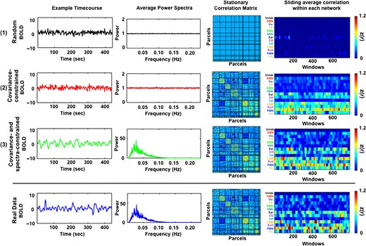

Generation of simulated data. (1) BOLD fMRI time series are simulated by first sampling random normal deviates. (2) These time series are projected onto the eigenvectors of the covariance matrix of real data averaged over ten 30-min sessions from each subject. (3) The projected time series then are matched to the average parcel-wise power spectrum of the real data by multiplication in the spectral domain. The final simulated data share the covariance and spectral features of real data (compare with bottom row) and are stationary by construction.

### Sliding Window Analysis

To estimate fluctuating connectivity over time, we adopt the commonly used sliding window strategy (Chang and Glover 2010; Hutchison et al. 2013b; Zalesky et al. 2014). Specifically, we extract time series from the cortical surface using the 333-area parcellation described in Gordon et al. (2016). Correlations are then computed at each time point between windowed samples of the time series tapered by a Gaussian function to center-weight the contribution of proximal time points. Window size is adjustable by changing the number of frames specified as the full width at half maximum. The time series are high-pass filtered at the frequency of the lowest frequency allowing a full cycle given the window length. Here, we use 100 s windows, according to the recommendation of Leonardi and Van De Ville, that the window length should exceed the slowest frequencies commonly assumed to comprise the BOLD signal (Leonardi and Van De Ville 2015; Zalesky and Breakspear 2015). Thus, the time series are high-pass filtered at 0.01 Hz. To illustrate sliding window fluctuations at the network level, we averaged all correlations between regions within each network at each window. Real and simulated time series of within-network connectivity can be seen in Fig. 1 in the far right column.

### State Analysis

To group the correlation patterns generated by the sliding window procedure, we adopted the *k*-means clustering algorithm commonly used in the literature (Allen et al. 2014; Hutchison and Morton 2015). The correlation patterns were dimensionality reduced from 55 278 (333 parcels × 333 parcels) to 30 dimensions by principal component analysis (PCA) prior to clustering to stabilize the computations and reduce computational demand. The Mahalanobis distance function was used to compute the separation between each window's correlation pattern and the *k*-means algorithm was iterated 100 times with random centroid positions to avoid local minima. Windows from all sessions and all subjects were used in the clustering, excluding 19 sessions (8 from 1 subject) that had more than half of their frames discarded because of excessive head motion. The window length for this analysis was 100 s and the windows were overlapping with a separation of 11 s between window centers, generating 155 windows per session. The windowed correlation patterns were mean-centered by run to eliminate run-level or subject-level features from contributing to the clustering result. *k*-means clustering was applied in the same manner to 81 sessions of simulated data, where each subject's BOLD power spectrum and covariance were used to generate the same number of sessions as were used in the real data. The cluster validity index was used to evaluate the quality of clustering for a range of cluster numbers (*k* = 2–10). The cluster validity index was computed as the average ratio of within-cluster distance to between-cluster distance.

### Kurtosis of Mardia

Nonstationarity in the context of electrophysiology is frequently evaluated using spectral descriptors (Wong et al. 2006; Halliday et al. 2009). Prior methods for evaluating nonstationarity in RSFC have relied on bivariate analyses, that is, analyzing multivariate data taken pairwise (Chang and Glover 2010; Hindriks et al. 2016). However, in these methods the number of free parameters grows in proportion to the square of the dimensionality of the data set, which limits computational tractability when the number of regions is large. Here, we take a different approach based on demonstrating that BOLD fMRI time series are consistent with a multivariate normal process. In greater detail, we evaluate the multivariate fourth moment (kurtosis) of BOLD fMRI data. Kurtosis values consistent with multivariate normality imply stationarity. On the other hand, kurtosis values inconsistent with multivariate normality may indicate either that (1) the data are multivariate normal but exhibit nonconstant covariance or (2) the data are stationary but not normally distributed. In addition, kurtosis is insensitive to nonstationarity of spectral content (see Discussion in Supplementary Materials). Thus, kurtosis estimation does not address stationarity in a strict sense. Nevertheless, kurtosis estimation is useful for investigating whether or not BOLD fMRI data exhibit nonconstant covariance, assuming multivariate normality.

where the superscript, T, denotes matrix transpose and the equality holds because the data have been made zero-mean during preprocessing. The squared Mahalonobis distance between any two frames, indexed by *j* and *k*, is